# Data Analytics based on model Industry 4.0

14/5/2017

## Abstract

One of the challenges of the manufacturing industry is the implementation of Lean Manufacturing Methodology on the production floor. The objective of this research is to measure the operating time of the CNC machines located in different cities from Mexico by using advance data analytics based on the model of Industry 4.0 to evaluate machine dead times and the percentage of operation per machine and plant.

## Objective

The main objective is to generate strategic knowledge that allows them to improve planning in the use of the machine and shifts of the personnel according to the estimated production to reduce cost of electricity consumption and workforce hours.

## Methodology

The following image shows the Methodology of the model that we used to get the app. As you can see we collect data from the CNC machines, which is stored in MySQL locally, then by the ETL process (Extraction, Transformation and Load) we send a table with all information needed to feed the Shiny App.

[figure not shown]

Project Methodology

## Plot

This plot shows two shifts of the machine **W11** from plant **MTY**. As you can see easily any Manager can see that this machine was not used at 3 pm, 9 pm, 10 pm and 11 pm. Four hours without working. This graph can be gotten in the Shiny app, and the user can choose: Date, Hours, Plant and machines.

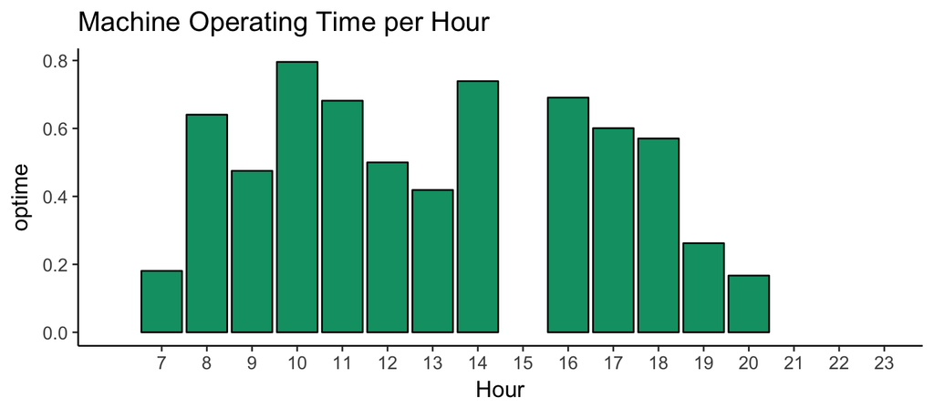

## Summary Table

This table shows the Operating Percentage per machine from 2017-04-17 to 2017-04-23. This table can be gotten from Shiny App and the user can use the range of time. With this table Manager can see as overal what is the operating time of their machines.

```
Source: local data frame [11 x 3]
Groups: plant [4]

    plant idmachine Porc_Op
   <fctr>    <fctr>   <dbl>
1     GDL       W01   50.39
2     GDL       W02   27.26
3     MTY       W03   32.19
4     MTY       W06   29.88
5     MTY       W07   23.42
6     MTY       W08   36.97
7     MTY       W09   27.99
8     MTY       W10   29.35
9     MTY       W11   26.05
10    QTO       W04   24.83
11   SALT       W11   30.84
```

| plant | idmachine | Porc_Op |
| --- | --- | --- |
| GDL | W01 | 50.39 |
| GDL | W02 | 27.26 |
| MTY | W03 | 32.19 |
| MTY | W06 | 29.88 |
| MTY | W07 | 23.42 |
| MTY | W08 | 36.97 |
| MTY | W09 | 27.99 |
| MTY | W10 | 29.35 |
| MTY | W11 | 26.05 |
| QTO | W04 | 24.83 |
| SALT | W11 | 30.84 |